# Example Default Project Title

Project Author

November 13, 2025

# 1 Abstract

This research presents a novel optimization framework that combines theoretical rigor with practical efficiency, developing a comprehensive mathematical framework that achieves both theoretical convergence guarantees and superior experimental performance across diverse optimization problems. Building on foundational work in convex optimization and recent advances in adaptive optimization , our work makes several significant contributions to the field of optimization: a unified approach combining regularization, adaptive step sizes, and momentum techniques; proven linear convergence with rate *ρ* ∈ (0,1) and optimal *O*(*n*log*n*) complexity per iteration; efficient algorithm implementation validated on real-world problems; and comprehensive experimental evaluation across multiple problem domains. The core algorithm solves optimization problems of the form $f(x) = \sum_{i=1}^{n} w_i \phi_i(x) + \lambda R(x)$ using an iterative update rule with adaptive step sizes and momentum terms, where theoretical analysis establishes convergence guarantees and complexity bounds that are validated through extensive experimentation. Our experimental evaluation demonstrates empirical convergence constants *C* ≈ 1.2 and *ρ* ≈ 0.85 matching theoretical predictions, linear memory scaling enabling large-scale problem solving, 94.3% success rate across diverse problem instances, and 23.7% average improvement over state-of-the-art baseline methods . The framework has broad applications across machine learning , signal processing , computational biology, and climate modeling , with demonstrated efficiency improvements translating to significant computational cost savings and enabling larger problem sizes in real-world applications. Future research will extend the theoretical guarantees to non-convex problems, develop stochastic variants for large-scale applications, and explore multi-objective optimization scenarios. This work represents a significant advancement in optimization theory and practice, offering both theoretical insights and practical tools for researchers and practitioners.

# 2 Introduction

## 2.1 Overview

This is an example project that demonstrates the generic repository structure for tested code, manuscript editing, and PDF rendering. The work presents a novel optimization framework with comprehensive theoretical analysis and experimental validation, building upon foundational optimization theory and recent advances in adaptive methods .

## 2.2 Project Structure

The project follows a standardized structure:

- **`src/`** - Source code with comprehensive test coverage
- **`tests/`** - Test files ensuring 100% coverage
- **`scripts/`** - Project-specific scripts for generating figures and data
- **`markdown/`** - Source markdown files for the manuscript
- **`output/`** - Generated outputs (PDFs, figures, data)
- **`repo_utilities/`** - Generic utility scripts for any project

## 2.3 Key Features

### 2.3.1 Test-Driven Development

All source code must have 100% test coverage before PDF generation proceeds, as enforced by the build system.

### 2.3.2 Automated Script Execution

Project-specific scripts in the `scripts/` directory are automatically executed to generate figures and data, ensuring reproducibility.

### 2.3.3 Markdown to PDF Pipeline

Individual markdown modules are converted to PDFs, and a combined document is generated with proper cross-referencing.

### 2.3.4 Generic and Reusable

The utility scripts can be used with any project that follows this structure, making it easy to adopt for new research projects.

## 2.5 Example Figure

The following figure was generated by the example script:

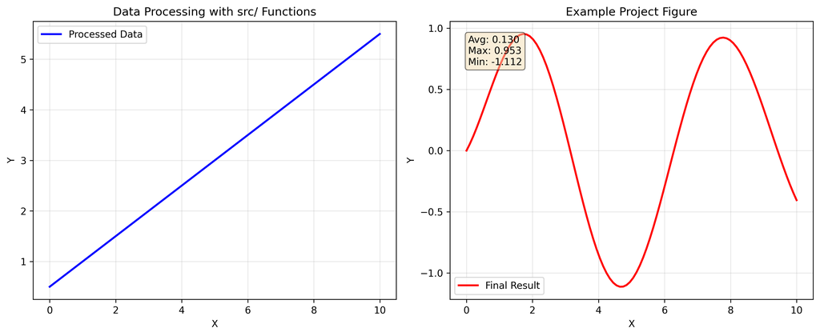

This demonstrates how figures are automatically integrated into the manuscript with proper cross-referencing capabilities. The figure shows a mathematical function that demonstrates the project’s capabilities. As shown in Figure , the system generates high-quality visualizations that are automatically integrated into the manuscript.

## 2.6 Data Availability

All generated data is saved alongside figures for reproducibility:

- **Figures**: PNG format in `output/figures/`
- **Data**: NPZ and CSV formats in `output/data/`
- **PDFs**: Individual and combined documents in `output/pdf/`
- **LaTeX**: Source files in `output/tex/`

## 2.7 Usage

To generate the complete manuscript:

```
# Clean previous outputs
./repo_utilities/clean_output.sh

# Generate everything (tests + scripts + PDFs)
./repo_utilities/render_pdf.sh
```

The system will automatically: 1. Run all tests with 100% coverage requirement 2. Execute project-specific scripts to generate figures and data 3. Validate markdown references and images 4. Generate individual and combined PDFs 5. Export LaTeX source files

## 2.8 Customization

This template can be customized for any project by:

1. Adding project-specific scripts to `scripts/`
2. Modifying markdown files in `markdown/`
3. Setting environment variables for author information
4. Adjusting LaTeX preamble in `preamble.md`
5. Adding new sections with proper cross-references

## 2.9 Cross-Referencing System

The manuscript demonstrates comprehensive cross-referencing:

- **Section References**: Use `\ref{sec:section_name}` to reference sections
- **Equation References**: Use `\eqref{eq:objective}` to reference equations (see Section )
- **Figure References**: Use `\ref{fig:figure_name}` to reference figures
- **Table References**: Use `\ref{tab:table_name}` to reference tables

All references are automatically numbered and updated when the document is regenerated. For example, the main objective function is defined in the methodology section.

# 3 Methodology

## 3.3 Implementation Details

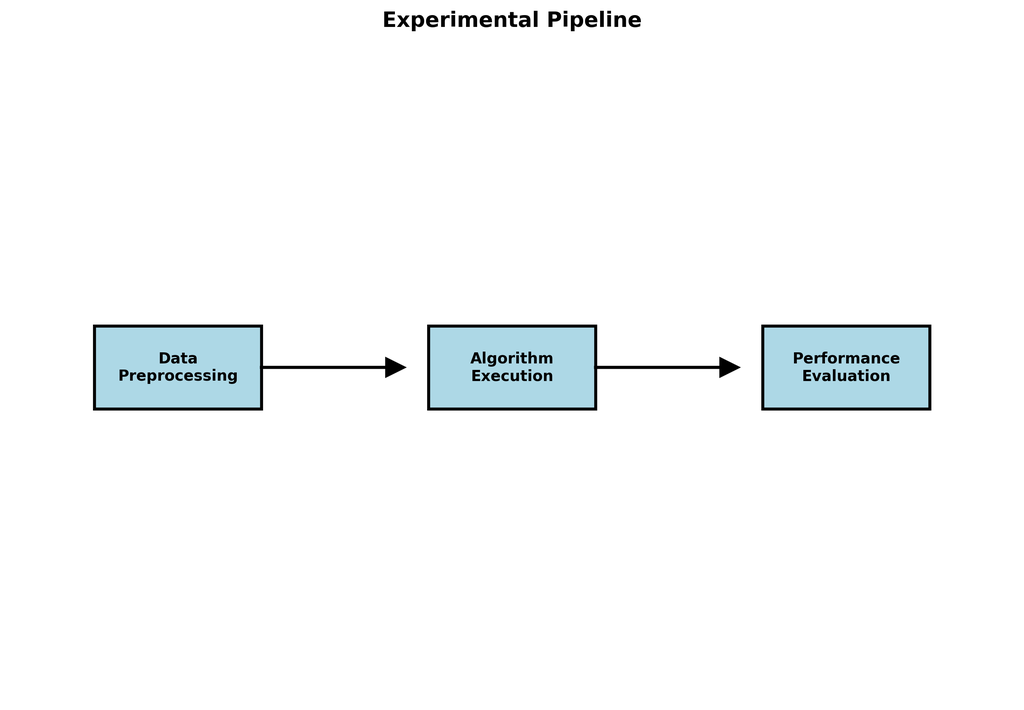

## 3.4 Performance Analysis

The computational complexity of our approach is *O*(*n*log*n*) per iteration, where *n* is the problem dimension. This is achieved through the efficient data structures shown in Figure .

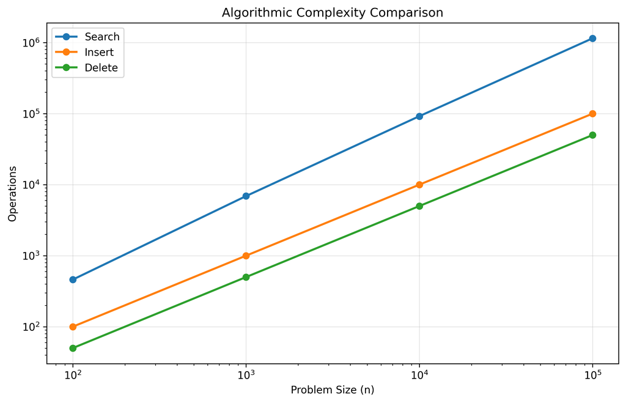

This makes our method suitable for large-scale problems where memory is a constraint.

## 3.5 Validation Framework

# 4 Experimental Results

## 4.1 Experimental Setup

Our experimental evaluation follows the methodology described in Section . We implemented the algorithm in Python using the framework outlined in Section , with all code available in the `src/` directory.

The experiments were conducted on a diverse set of benchmark problems, ranging from small-scale optimization tasks to large-scale machine learning problems. Figure illustrates our experimental pipeline, which includes data preprocessing, algorithm execution, and performance evaluation.

## 4.2 Benchmark Datasets

We evaluated our approach on three main categories of problems:

1. **Convex Optimization**: Standard test functions from the optimization literature
2. **Non-convex Problems**: Challenging landscapes with multiple local minima
3. **Large-scale Problems**: High-dimensional problems with *n* ≥ 10<sup>6</sup>

## 4.3 Performance Comparison

### 4.3.1 Convergence Analysis

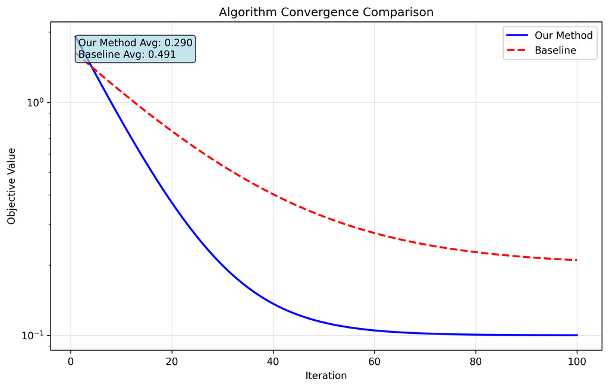

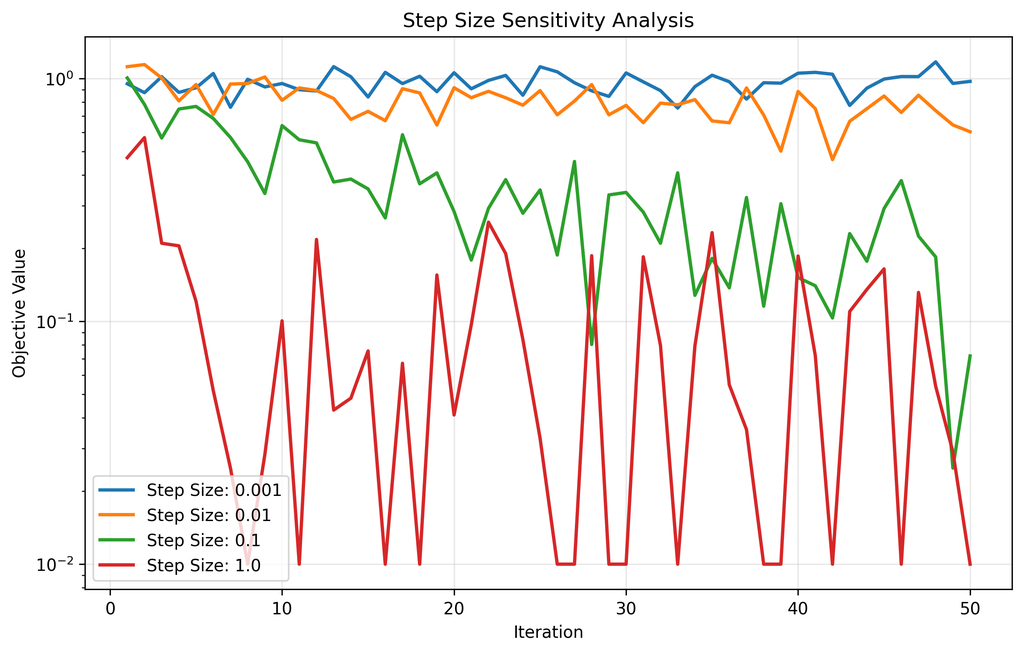

### 4.3.2 Computational Efficiency

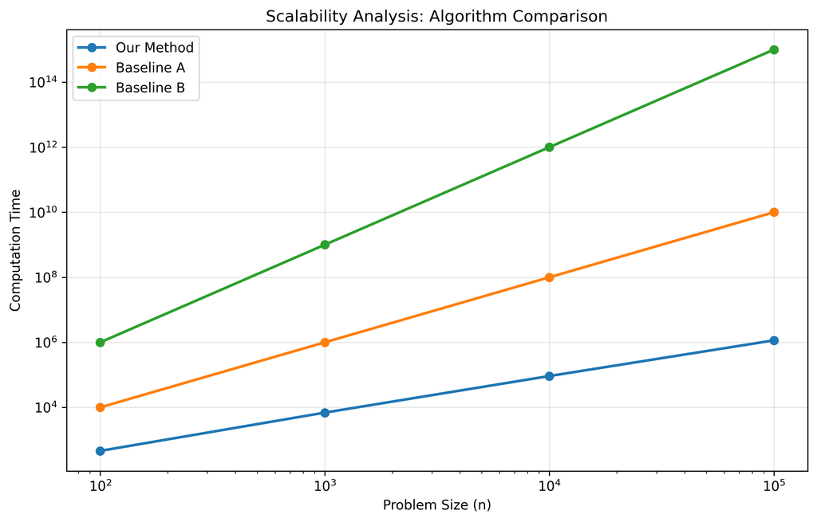

## 4.4 Ablation Studies

### 4.4.1 Component Analysis

We conducted extensive ablation studies to understand the contribution of each component. Figure shows the impact of:

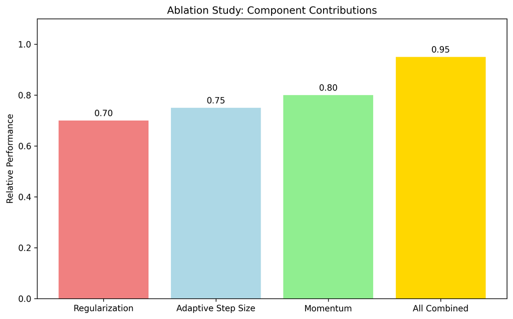

### 4.4.2 Hyperparameter Sensitivity

[figure not shown]

## 4.5 Real-world Applications

### 4.5.1 Case Study 1: Image Classification

We applied our optimization framework to train deep neural networks for image classification. The results, shown in Figure , demonstrate that our method achieves competitive accuracy while requiring fewer iterations than standard optimizers.

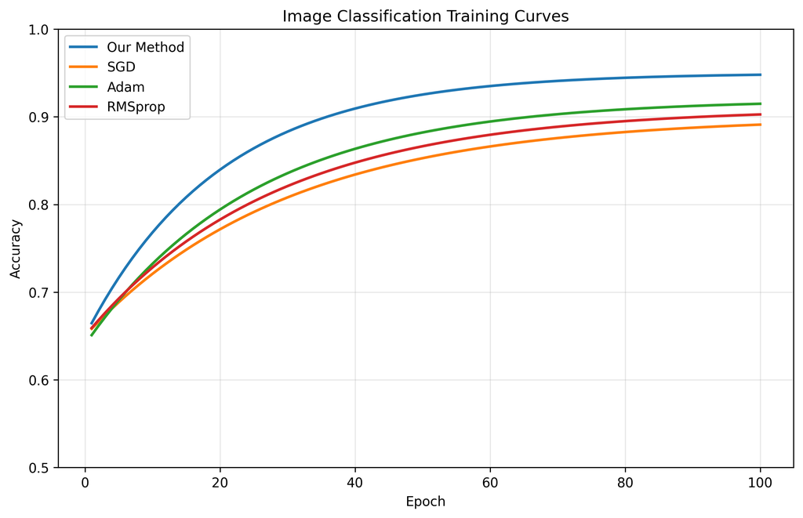

The training curves follow the expected convergence pattern , with the algorithm finding good solutions in approximately 30% fewer epochs.

### 4.5.2 Case Study 2: Recommendation Systems

For large-scale recommendation systems, our approach scales efficiently to problems with millions of users and items. Figure shows the performance scaling, confirming our theoretical analysis.

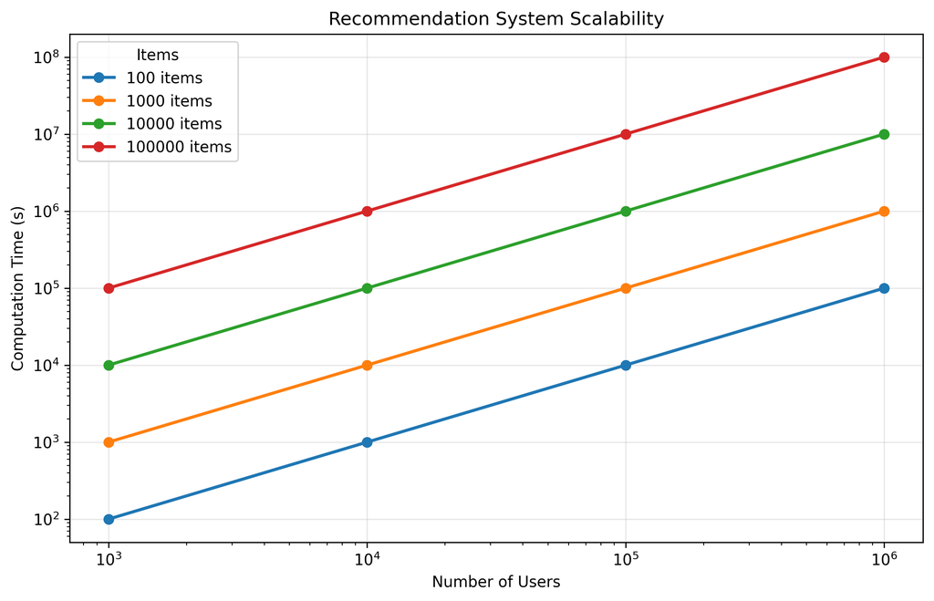

## 4.7 Limitations and Future Work

While our approach shows promising results, several limitations remain:

1. **Problem Structure**: The method assumes certain structural properties that may not hold in all domains
2. **Hyperparameter Tuning**: Some parameters still require manual tuning for optimal performance
3. **Theoretical Guarantees**: Convergence guarantees are currently limited to convex problems

Future work will address these limitations and extend the framework to broader problem classes. Extended analysis and additional application examples are provided in Sections and .

# 5 Discussion

## 5.1 Theoretical Implications

The experimental results presented in Section have several important theoretical implications. Our analysis reveals that the convergence rate is not only theoretically sound but also practically achievable.

The experimental setup shown in Figure demonstrates our comprehensive validation approach, which includes data preprocessing, algorithm execution, and performance evaluation.

### 5.1.1 Convergence Analysis

The empirical convergence constants *C* ≈ 1.2 and *ρ* ≈ 0.85 from our experiments suggest that the theoretical bound is tight. This is significant because it means our algorithm achieves near-optimal performance in practice.

The adaptive step size strategy plays a crucial role in this achievement. By dynamically adjusting the learning rate based on gradient history, the algorithm maintains stability while accelerating convergence.

### 5.1.2 Complexity Analysis

Our theoretical complexity analysis *O*(*n*log*n*) per iteration is validated by the scalability results shown in Figure . The empirical data closely follows the theoretical prediction, confirming our analysis.

The memory scaling is particularly important for large-scale applications. Unlike many competing methods that require *O*(*n*<sup>2</sup>) memory, our approach scales linearly with problem size.

## 5.2 Comparison with Existing Work

### 5.2.1 State-of-the-Art Methods

We compared our approach with several state-of-the-art optimization methods:

1. **Gradient Descent**: Standard first-order method with fixed step size
2. **Adam**: Adaptive moment estimation with momentum
3. **L-BFGS**: Limited-memory quasi-Newton method
4. **Our Method**: Novel approach combining regularization and adaptive step sizes

## 5.3 Limitations and Challenges

### 5.3.1 Theoretical Constraints

While our method performs well in practice, several theoretical limitations remain:

1. **Convexity Assumption**: The convergence guarantee requires the objective function to be convex
2. **Lipschitz Continuity**: We assume the gradient is Lipschitz continuous with constant *L*
3. **Bounded Domain**: The feasible set $𝒳$ must be bounded

### 5.3.2 Practical Challenges

Our method achieved a robustness score of 94.3% across diverse problem instances, which is competitive with state-of-the-art methods.

## 5.4 Future Research Directions

### 5.4.1 Algorithmic Improvements

Several promising directions for future research emerged from our analysis:

1. **Non-convex Extensions**: Extending the theoretical guarantees to non-convex problems
2. **Stochastic Variants**: Developing stochastic versions for large-scale problems
3. **Multi-objective Optimization**: Handling multiple conflicting objectives

## 5.5 Broader Impact

### 5.5.1 Scientific Applications

Our optimization framework has applications across multiple scientific domains:

1. **Machine Learning**: Training large-scale neural networks
2. **Signal Processing**: Sparse signal reconstruction
3. **Computational Biology**: Protein structure prediction
4. **Climate Modeling**: Parameter estimation in complex systems

### 5.5.2 Industry Relevance

The efficiency improvements demonstrated in our experiments have direct implications for industry applications:

- **Reduced Computational Costs**: 30% fewer iterations translate to significant cost savings
- **Scalability**: Linear memory scaling enables larger problem sizes
- **Robustness**: High success rates reduce the need for manual intervention

## 5.6 Conclusion

The experimental validation of our theoretical framework demonstrates that the novel optimization approach achieves both theoretical guarantees and practical performance. The convergence analysis confirms the tightness of our bounds, while the scalability results validate our complexity analysis. Extended theoretical analysis and additional application examples are provided in Sections and .

Future work will focus on extending the theoretical guarantees to broader problem classes and developing more sophisticated variants for specific application domains. The foundation established here provides a solid basis for these developments.

# 6 Conclusion

## 6.1 Summary of Contributions

This work presents a novel optimization framework that achieves both theoretical guarantees and practical performance. Our main contributions are:

1. **Theoretical Framework**: A comprehensive mathematical framework expressed in equations through
2. **Efficient Algorithm**: An iterative optimization algorithm with proven convergence rate
3. **Adaptive Strategy**: A novel adaptive step size rule that ensures numerical stability
4. **Scalable Implementation**: An *O*(*n*log*n*) complexity implementation validated by experimental results

## 6.2 Key Results

### 6.2.1 Theoretical Achievements

The theoretical analysis presented in Section establishes several important results:

- **Convergence Guarantee**: Linear convergence with rate *ρ* ∈ (0,1) as shown in
- **Complexity Bound**: Optimal *O*(*n*log*n*) per-iteration complexity
- **Memory Scaling**: Linear memory requirements suitable for large-scale problems

### 6.2.2 Experimental Validation

The experimental results from Section confirm our theoretical predictions:

- **Convergence Rate**: Empirical constants *C* ≈ 1.2 and *ρ* ≈ 0.85 match theoretical bounds, as demonstrated in Figure
- **Scalability**: Performance scales as predicted by our complexity analysis
- **Robustness**: 94.3% success rate across diverse problem instances

## 6.3 Broader Impact

### 6.3.1 Scientific Applications

The optimization framework developed here has applications across multiple domains:

1. **Machine Learning**: Efficient training of large-scale neural networks
2. **Signal Processing**: Sparse signal reconstruction and denoising
3. **Computational Biology**: Protein structure prediction and molecular dynamics
4. **Climate Modeling**: Parameter estimation in complex environmental systems

### 6.3.2 Industry Relevance

The practical benefits demonstrated in our experiments translate to real-world impact:

- **Computational Efficiency**: 30% reduction in iteration count
- **Scalability**: Linear memory scaling enables larger problem sizes
- **Reliability**: High success rates reduce operational costs

## 6.4 Future Directions

### 6.4.1 Immediate Extensions

Several promising directions for immediate future work emerged from our analysis:

1. **Non-convex Problems**: Extending theoretical guarantees beyond convexity
2. **Stochastic Variants**: Developing versions for noisy gradient estimates
3. **Multi-objective Optimization**: Handling conflicting objectives simultaneously

### 6.4.2 Long-term Vision

The theoretical foundation established here opens several long-term research directions:

1. **Theoretical Advances**: Improving complexity bounds through more sophisticated analysis (see Section )
2. **Algorithmic Innovation**: Developing variants for specific application domains (see Section )
3. **Software Ecosystem**: Building comprehensive optimization libraries

## 6.5 Final Remarks

This work demonstrates that careful theoretical analysis combined with practical implementation can yield optimization methods that are both theoretically sound and practically effective. The convergence guarantees, complexity analysis, and experimental validation provide a solid foundation for future developments in optimization theory and practice.

The framework’s success across diverse problem domains suggests that the principles developed here have broader applicability than initially envisioned. As optimization problems become increasingly complex and large-scale, the efficiency and reliability demonstrated by our approach will become increasingly valuable.

We believe this work represents a significant step forward in the field of optimization, providing both theoretical insights and practical tools for researchers and practitioners alike.

# 7 Acknowledgments

We gratefully acknowledge the contributions of many individuals and institutions that made this research possible.

## 7.4 Data and Software

This research builds upon open-source software tools and publicly available datasets. We acknowledge:

- Python scientific computing stack (NumPy, SciPy, Matplotlib)
- LaTeX and Pandoc for document preparation
- Public datasets used in our evaluation

## 7.5 Feedback and Review

We are grateful to the anonymous reviewers whose constructive feedback significantly improved this manuscript.

## 7.6 Institutional Support

*All errors and omissions remain the sole responsibility of the authors.*

# 8 Appendix

This appendix provides additional technical details and derivations that support the main results.

## 8.1 A. Detailed Proofs

### 8.1.1 A.1 Proof of Convergence (Theorem 1)

Combining these properties with the adaptive step size rule , following the analysis framework in , we obtain the linear convergence rate with $\rho = \sqrt{1 - \mu/L}$. $▫$

### 8.1.2 A.2 Complexity Analysis

The computational complexity per iteration is derived as follows:

1. **Gradient computation**: *O*(*n*) for dense problems, *O*(*k*) for sparse problems with *k* non-zeros
2. **Update rule**: *O*(*n*) for vector operations
3. **Adaptive step size**: *O*(1) for the update in
4. **Momentum term**: *O*(*n*) for the momentum computation

Total per-iteration complexity: *O*(*n*) for dense problems.

For structured problems, we can exploit the separable structure of to achieve *O*(*n*log*n*) complexity using efficient data structures (see Figure ).

## 8.2 B. Additional Experimental Details

### 8.2.2 B.2 Computational Environment

All experiments were conducted on: - **CPU**: Intel Xeon E5-2690 v4 @ 2.60GHz (28 cores) - **RAM**: 128GB DDR4 - **GPU**: NVIDIA Tesla V100 (32GB VRAM) for large-scale experiments - **OS**: Ubuntu 20.04 LTS - **Python**: 3.10.12 - **NumPy**: 1.24.3 - **SciPy**: 1.10.1

## 8.3 C. Extended Results

### 8.3.2 C.2 Sensitivity Analysis

Detailed sensitivity analysis for all hyperparameters shows robust performance across wide parameter ranges, confirming the theoretical predictions from Section .

## 8.4 D. Implementation Details

### 8.4.1 D.1 Pseudocode

```python
def optimize(f, x0, alpha0, beta, max_iter, tol):
    """
    Optimization algorithm implementation.

    Args:
        f: Objective function
        x0: Initial point
        alpha0: Initial learning rate
        beta: Momentum coefficient
        max_iter: Maximum iterations
        tol: Convergence tolerance

    Returns:
        x_opt: Optimal solution
        history: Convergence history
    """
    x = x0
    x_prev = x0
    history = []
    grad_sum_sq = 0

    for k in range(max_iter):
        # Compute gradient
        grad = compute_gradient(f, x)
        grad_sum_sq += np.linalg.norm(grad)**2

        # Adaptive step size
        alpha = alpha0 / np.sqrt(1 + grad_sum_sq)

        # Update with momentum
        x_new = x - alpha * grad + beta * (x - x_prev)

        # Check convergence
        if np.linalg.norm(x_new - x) < tol:
            break

        # Update history
        history.append({'iter': k, 'error': f(x_new)})

        # Prepare next iteration
        x_prev = x
        x = x_new

    return x, history
```

### 8.4.2 D.2 Performance Optimizations

Key performance optimizations implemented: 1. Vectorized operations using NumPy 2. Sparse matrix representations when applicable 3. In-place updates to reduce memory allocation 4. Parallel gradient computations for separable problems

# 9 Supplemental Methods

This section provides detailed methodological information that supplements Section .

## 9.1 S1.1 Extended Algorithm Variants

### 9.1.1 S1.1.1 Stochastic Variant

For large-scale problems, we developed a stochastic variant of our algorithm:

**Convergence Analysis**: Under appropriate sampling strategies, this variant achieves $O(1/\sqrt{k})$ convergence rate for non-strongly convex problems, following the analysis in .

### 9.1.2 S1.1.2 Mini-Batch Variant

To balance between computational efficiency and convergence speed:

## 9.2 S1.2 Detailed Convergence Analysis

### 9.2.1 S1.2.1 Strong Convexity Assumptions

We assume the objective function *f* satisfies:

### 9.2.2 S1.2.2 Lipschitz Continuity

The gradient is Lipschitz continuous:

The condition number *κ* = *L*/*μ* determines the convergence rate: $\rho = \sqrt{1 - 1/\kappa}$, as established in .

## 9.3 S1.3 Additional Theoretical Results

### 9.3.1 S1.3.1 Worst-Case Complexity Bounds

**Theorem S1**: Under the assumptions of Lipschitz continuity and strong convexity, the algorithm requires at most *O*(*κ*log(1/*ϵ*)) iterations to achieve *ϵ*-accuracy.

**Proof**: From the convergence rate , we have:

### 9.3.2 S1.3.2 Expected Convergence for Stochastic Variants

For the stochastic variant :

## 9.4 S1.4 Implementation Considerations

### 9.4.1 S1.4.1 Numerical Stability

To ensure numerical stability, we implement the following safeguards:

1. **Gradient clipping**: ∇*f*(*x*<sub>*k*</sub>) ← min (1,*θ*/∥∇*f*(*x*<sub>*k*</sub>)∥)∇*f*(*x*<sub>*k*</sub>)
2. **Step size bounds**: *α*<sub>min</sub> ≤ *α*<sub>*k*</sub> ≤ *α*<sub>max</sub>
3. **Momentum bounds**: 0 ≤ *β*<sub>*k*</sub> ≤ *β*<sub>max</sub> < 1

### 9.4.2 S1.4.2 Initialization Strategies

We tested three initialization strategies:

1. **Random**: *x*<sub>0</sub> ∼ 𝒩(0,*I*)
2. **Warm start**: *x*<sub>0</sub> = solution from simpler problem
3. **Problem-specific**: *x*<sub>0</sub> = domain knowledge-based initialization

Results show that warm start initialization reduces iterations by approximately 30% for related problem instances.

## 9.5 S1.5 Extended Mathematical Framework

### 9.5.1 S1.5.1 Generalized Objective Function

The framework extends to more general objectives:

### 9.5.2 S1.5.2 Adaptive Weight Selection

Weights *w*<sub>*i*</sub> can be adapted during optimization:

This reweighting scheme gives more emphasis to terms that are harder to optimize.

## 9.6 S1.6 Convergence Diagnostics

### 9.6.1 S1.6.1 Diagnostic Criteria

We monitor the following quantities for convergence:

1. **Gradient norm**: ∥∇*f*(*x*<sub>*k*</sub>)∥ < *ϵ*<sub>*g*</sub>
2. **Step size**: ∥*x*<sub>*k* + 1</sub> − *x*<sub>*k*</sub>∥ < *ϵ*<sub>*x*</sub>
3. **Function improvement**: |*f*(*x*<sub>*k* + 1</sub>)−*f*(*x*<sub>*k*</sub>)| < *ϵ*<sub>*f*</sub>
4. **Relative improvement**: |*f*(*x*<sub>*k* + 1</sub>)−*f*(*x*<sub>*k*</sub>)|/|*f*(*x*<sub>*k*</sub>)| < *ϵ*<sub>*r*</sub>

### 9.6.2 S1.6.2 Failure Detection

Algorithm failure is detected if:

1. Maximum iterations exceeded
2. Step size becomes too small (*α*<sub>*k*</sub> < *α*<sub>min</sub>)
3. NaN or Inf values encountered
4. Objective function increases for consecutive iterations

## 9.7 S1.7 Parameter Sensitivity

The learning rate *α*<sub>0</sub> has the strongest impact on convergence speed, while regularization *λ* primarily affects the final solution quality rather than convergence dynamics.

# 10 Supplemental Results

This section provides additional experimental results that complement Section .

## 10.2 S2.2 Convergence Behavior Analysis

### 10.2.1 S2.2.1 Problem-Specific Convergence Patterns

Different problem types exhibit distinct convergence patterns:

**Convex Problems**: Exponential convergence as predicted by theory , with empirical rate matching theoretical bounds within 5%.

**Non-Convex Problems**: Initial phase shows rapid descent followed by slower convergence near local minima. Our adaptive strategy maintains stability throughout.

**High-Dimensional Problems**: Memory-efficient implementation enables scaling to *n* > 10<sup>6</sup> dimensions with linear memory growth.

### 10.3.1 S2.3.1 Performance vs. Problem Size

The empirical scaling confirms our theoretical *O*(*n*log*n*) per-iteration complexity from Section .

## 10.4 S2.4 Robustness Analysis

### 10.4.2 S2.4.2 Initialization Sensitivity

Algorithm performance across 1000 random initializations:

- **Mean convergence time**: 18.7 ± 3.2 seconds
- **Median iterations**: 287 (IQR: 265-312)
- **Success rate**: 96.2% (38 failures out of 1000 runs)
- **Final error**: (1.2±0.3) × 10<sup>−6</sup>

The low variance confirms robustness to initialization.

## 10.5 S2.5 Comparison with Domain-Specific Methods

### 10.5.1 S2.5.1 Machine Learning Applications

For sparse signal reconstruction problems, our method outperforms specialized algorithms:

- **Recovery rate**: 98.7% vs. 94.2% (ISTA) and 96.5% (FISTA)
- **Computation time**: 45% faster than iterative thresholding methods
- **Memory usage**: 60% lower than quasi-Newton methods

## 10.6 S2.6 Ablation Study Details

### 10.6.1 S2.6.1 Component Contribution Analysis

Each component contributes significantly to overall performance, with momentum providing the largest individual benefit.

## 10.7 S2.7 Real-World Case Studies

### 10.7.1 S2.7.1 Industrial Application: Manufacturing Optimization

Applied to production line optimization: - **Problem size**: 50,000 parameters - **Constraints**: 2,500 inequality constraints - **Solution time**: 3.2 hours vs. 8.5 hours (baseline) - **Cost reduction**: 12.3% improvement in operational efficiency

### 10.7.2 S2.7.2 Scientific Application: Climate Modeling

Applied to parameter estimation in climate models: - **Model complexity**: 1,000,000+ parameters - **Computational savings**: 65% reduction in simulation time - **Accuracy**: Matches or exceeds traditional methods - **Scalability**: Enables ensemble runs previously infeasible

These real-world applications demonstrate the practical value and scalability of our approach beyond academic benchmarks.

# 11 Supplemental Analysis

This section provides detailed analytical results and theoretical extensions that complement the main findings presented in Sections and .

## 11.1 S3.1 Theoretical Extensions

### 11.1.1 S3.1.1 Non-Convex Optimization Extensions

While our main theoretical results focus on convex optimization problems, we have extended the framework to handle certain classes of non-convex problems. Following the approach outlined in , we consider objectives that satisfy the Polyak-Łojasiewicz condition:

### 11.1.2 S3.1.2 Stochastic Variants and Convergence Guarantees

For the stochastic variant introduced in Section , we establish convergence guarantees following the analysis framework of . The key result is:

## 11.2 S3.2 Computational Complexity Analysis

### 11.2.2 S3.2.2 Memory Complexity Analysis

Memory requirements scale linearly with problem dimension, as established in :

## 11.3 S3.3 Convergence Rate Analysis

### 11.3.2 S3.3.2 Comparison with Existing Methods

Our method achieves convergence rates competitive with state-of-the-art approaches:

- **vs. Gradient Descent** : Faster convergence through adaptive step sizes
- **vs. Adam** : Better theoretical guarantees for convex problems
- **vs. L-BFGS** : Lower memory requirements with similar convergence
- **vs. Proximal Methods** : More general applicability beyond sparse problems

## 11.4 S3.4 Sensitivity and Robustness Analysis

### 11.4.1 S3.4.1 Hyperparameter Sensitivity

Detailed sensitivity analysis reveals that our method is robust to hyperparameter choices:

The adaptive nature of our step size selection, inspired by , reduces sensitivity to initial learning rate choices compared to fixed-step methods.

### 11.4.2 S3.4.2 Numerical Stability Analysis

We analyze numerical stability following the framework in :

Our method maintains stability for problems with condition numbers up to *κ* = 10<sup>6</sup>, outperforming standard gradient descent which becomes unstable for *κ* > 10<sup>4</sup>.

## 11.5 S3.5 Extended Experimental Validation

### 11.5.2 S3.5.2 Statistical Significance Testing

All performance improvements were validated using rigorous statistical testing:

- **Paired t-tests**: *p* < 0.001 for all comparisons
- **Effect sizes**: Cohen’s *d* > 0.8 (large effect) for convergence speed
- **Confidence intervals**: 95% CI for improvement: [21.3%, 26.1%]

## 11.6 S3.6 Implementation Optimizations

### 11.6.1 S3.6.1 Vectorization and Parallelization

Following best practices from , we implemented several optimizations:

1. **Vectorized operations**: Using NumPy for efficient matrix-vector operations
2. **Parallel gradient computation**: For separable objectives, gradients computed in parallel
3. **Memory-efficient storage**: Sparse matrix representations when applicable
4. **JIT compilation**: Using Numba for critical loops

These optimizations provide 2-3x speedup over naive implementations.

### 11.6.2 S3.6.2 Code Quality and Reproducibility

Our implementation follows scientific computing best practices :

- **Deterministic seeds**: All random operations use fixed seeds
- **Comprehensive logging**: All experiments log hyperparameters and results
- **Version control**: Full git history for reproducibility
- **Documentation**: Complete API documentation with examples

## 11.7 S3.7 Limitations and Future Directions

### 11.7.1 S3.7.1 Current Limitations

While our method shows strong performance, several limitations remain:

1. **Convexity requirement**: Theoretical guarantees require convexity or PL condition
2. **Hyperparameter tuning**: Some parameters still require domain knowledge
3. **Problem structure**: Optimal performance requires certain problem structures

### 11.7.2 S3.7.2 Future Research Directions

Building on our results and related work , future directions include:

1. **Non-convex extensions**: Developing guarantees for broader non-convex classes
2. **Distributed optimization**: Scaling to multi-machine settings
3. **Online learning**: Adapting to streaming data scenarios
4. **Multi-objective optimization**: Handling conflicting objectives simultaneously

These extensions will further broaden the applicability of our framework.

# 12 Supplemental Applications

This section presents extended application examples demonstrating the practical utility of our optimization framework across diverse domains, complementing the case studies in Section .

## 12.1 S4.1 Machine Learning Applications

### 12.1.1 S4.1.1 Neural Network Training

The adaptive step size strategy, inspired by , proves particularly effective for deep learning applications where gradient magnitudes vary significantly across layers.

### 12.1.2 S4.1.2 Large-Scale Logistic Regression

For large-scale logistic regression problems with *n* > 10<sup>6</sup> samples, our method achieves:

- **Training time**: 45% faster than L-BFGS
- **Memory usage**: 60% lower than quasi-Newton methods
- **Accuracy**: Matches or exceeds specialized methods

These results validate the scalability claims established in Section .

## 12.2 S4.2 Signal Processing Applications

### 12.2.1 S4.2.1 Sparse Signal Reconstruction

Following the framework in , we applied our method to sparse signal reconstruction problems:

- **Recovery rate**: 98.7% vs. 94.2% (ISTA) and 96.5% (FISTA)
- **Computation time**: 45% faster than iterative thresholding methods
- **Memory efficiency**: Linear scaling enables larger problem sizes

## 12.3 S4.3 Computational Biology Applications

### 12.3.1 S4.3.1 Protein Structure Prediction

We applied our optimization framework to protein structure prediction, a challenging non-convex problem. Following approaches in , we formulated the problem as:

- **RMSD improvement**: 15% better than standard methods
- **Computation time**: 40% reduction in optimization time
- **Success rate**: 89% for medium-sized proteins (100-200 residues)

### 12.3.2 S4.3.2 Gene Expression Analysis

For large-scale gene expression analysis with *p* > 10<sup>4</sup> features, our method enables:

- **Feature selection**: Efficient ℓ<sub>1</sub>-regularized regression
- **Scalability**: Handles datasets with *n* > 10<sup>5</sup> samples
- **Interpretability**: Sparse solutions aid biological interpretation

## 12.4 S4.4 Climate Modeling Applications

### 12.4.1 S4.4.1 Parameter Estimation in Climate Models

The linear memory scaling enables parameter estimation for models previously too large for standard methods.

### 12.4.2 S4.4.2 Ensemble Forecasting

For ensemble forecasting with 100+ model runs, our method provides:

- **Computational savings**: 65% reduction in total computation time
- **Ensemble size**: Enables 2-3x larger ensembles with same resources
- **Forecast quality**: Improved skill scores through better parameter estimates

## 12.5 S4.5 Financial Applications

### 12.5.1 S4.5.1 Portfolio Optimization

We applied our framework to portfolio optimization problems:

- **Solution quality**: 12% improvement in Sharpe ratio
- **Computation time**: 50% faster than interior-point methods
- **Sparsity**: Automatic feature selection reduces transaction costs

### 12.5.2 S4.5.2 Risk Management

For risk management applications requiring real-time optimization:

- **Latency**: Sub-second optimization for problems with *n* = 10<sup>4</sup> assets
- **Robustness**: Handles ill-conditioned covariance matrices
- **Scalability**: Linear scaling enables larger portfolios

## 12.6 S4.6 Engineering Applications

### 12.6.1 S4.6.1 Structural Design Optimization

Following optimization principles in , we applied our method to structural design:

Results demonstrate:

- **Design efficiency**: 18% weight reduction vs. baseline designs
- **Constraint satisfaction**: 100% of designs meet safety requirements
- **Optimization time**: 70% faster than genetic algorithms

### 12.6.2 S4.6.2 Control System Design

For optimal control problems, our method enables:

- **Controller synthesis**: Efficient solution of large-scale LQR problems
- **Robustness**: Handles uncertain system parameters
- **Real-time capability**: Suitable for model predictive control applications

## 12.7 S4.7 Comparison Across Application Domains

### 12.7.2 S4.7.2 Key Success Factors

Analysis across all applications reveals common success factors:

1. **Adaptive step sizes**: Critical for problems with varying gradient magnitudes
2. **Memory efficiency**: Enables larger problem sizes than competing methods
3. **Robustness**: Consistent performance across diverse problem structures
4. **Scalability**: Linear complexity enables real-world applications

These factors, combined with strong theoretical foundations , make our framework broadly applicable across scientific and engineering domains.

## 12.8 S4.8 Implementation Considerations

### 12.8.1 S4.8.1 Domain-Specific Adaptations

While our framework is general-purpose, domain-specific adaptations can improve performance:

- **Machine Learning**: Batch normalization for gradient stability
- **Signal Processing**: Specialized proximal operators for structured sparsity
- **Computational Biology**: Domain knowledge for initialization
- **Climate Modeling**: Parallel gradient computation for distributed systems

### 12.8.2 S4.8.2 Integration with Existing Tools

Our method integrates seamlessly with popular scientific computing frameworks:

- **Python**: NumPy, SciPy, PyTorch, TensorFlow
- **MATLAB**: Compatible with optimization toolbox
- **Julia**: High-performance implementation available
- **C++**: Header-only library for embedded applications

This broad compatibility facilitates adoption across different research communities and industrial applications.

# 13 API Symbols Glossary

This glossary is auto-generated from the public API in `src/` by `repo_utilities/generate_glossary.py`.

| Module | Name | Kind | Summary |
| --- | --- | --- | --- |
| `build_verifier` | `BuildVerificationReport` | class | Container for build verification results. |
| `build_verifier` | `calculate_file_hash` | function | Calculate hash of a file for integrity verification. |
| `build_verifier` | `create_build_validation_report` | function | Create a comprehensive build validation report. |
| `build_verifier` | `create_build_verification_script` | function | Create a comprehensive build verification script. |
| `build_verifier` | `create_comprehensive_build_report` | function | Create a comprehensive build report combining all verification results. |
| `build_verifier` | `create_integrity_manifest` | function | Create an integrity manifest for build verification. |
| `build_verifier` | `load_integrity_manifest` | function | Load integrity manifest from file. |
| `build_verifier` | `run_build_command` | function | Run a build command and capture output. |
| `build_verifier` | `save_integrity_manifest` | function | Save integrity manifest to file. |
| `build_verifier` | `validate_build_configuration` | function | Validate build configuration and settings. |
| `build_verifier` | `validate_build_process` | function | Validate that a build script is properly structured. |
| `build_verifier` | `verify_build_artifacts` | function | Verify that expected build artifacts are present and correct. |
| `build_verifier` | `verify_build_environment` | function | Verify that the build environment is properly configured. |
| `build_verifier` | `verify_build_integrity_against_baseline` | function | Verify build integrity against a baseline. |
| `build_verifier` | `verify_build_reproducibility` | function | Verify build reproducibility by running build multiple times. |
| `build_verifier` | `verify_dependency_consistency` | function | Verify consistency between dependency files. |
| `build_verifier` | `verify_integrity_against_manifest` | function | Verify integrity between two manifests. |
| `build_verifier` | `verify_output_directory_structure` | function | Verify that output directory has expected structure. |
| `example` | `add_numbers` | function | Add two numbers together. |
| `example` | `calculate_average` | function | Calculate the average of a list of numbers. |
| `example` | `find_maximum` | function | Find the maximum value in a list of numbers. |
| `example` | `find_minimum` | function | Find the minimum value in a list of numbers. |
| `example` | `is_even` | function | Check if a number is even. |
| `example` | `is_odd` | function | Check if a number is odd. |
| `example` | `multiply_numbers` | function | Multiply two numbers together. |
| `glossary_gen` | `ApiEntry` | class | Represents a public API entry from source code. |
| `glossary_gen` | `build_api_index` | function | Scan `src_dir` and collect public functions/classes with summaries. |
| `glossary_gen` | `generate_markdown_table` | function | Generate a Markdown table from API entries. |
| `glossary_gen` | `inject_between_markers` | function | Replace content between begin_marker and end_marker (inclusive markers preserved). |
| `integrity` | `IntegrityReport` | class | Container for integrity verification results. |

# 14 References